# P. tremula genome self-self Blast results parsing

Nicolas Delhomme

2015-01-28

# 1 Setup

Set the working dir

```r
setwd("/mnt/picea/projects/aspseq/tremula_tremuloides_comp/BLAST-subset")
```

```r
# #' Load libraries
suppressPackageStartupMessages(library(Biostrings))
suppressPackageStartupMessages(library(LSD))
suppressPackageStartupMessages(library(RColorBrewer))
suppressPackageStartupMessages(library(VennDiagram))
```

Source helpers

```r
source("~/Git/UPSCb/src/R/blastUtilities.R")
source('~/Git/UPSCb/src/R/plot.multidensity.R')
```

Create a palette

```r
pal <- brewer.pal(5,"Dark2")
```

# 2 Initial attempt

To enhance the speed, I have split the original file in subset of 10000 lines. The issue is though, that some scaffold HSPs will be in separate files and need to be recalculated afterwards

```r
PotraBLAST <- mclapply(dir(".",pattern=".*\\.blt"),
  readBlast,ignoreSelf = TRUE,
                        format=c("query.id",
                                 "subject.id",
                                 "percent.identity",
                                 "alignment.length",
                                 "mismatches",
                                 "gap.opening",
                                 "query.start",
                                 "query.end",
                                 "subject.start",
                                 "subject.end",
                                 "e.value",
                                 "bit.score",
                                 "query.length",
                                 "subject.length"),
                        plot = FALSE,mc.cores=4L)
```

# 3 Process all the chunks

And re-calculate the scaffold values which occured when the original file was split

```r
dat <- do.call(rbind,mclapply((1:length(PotraBLAST)),function(i,bl){

  ## get the scaffolds in the previous chunk
  if(i==1){
    p.scfs = ""
  } else {
    p.scfs <- unique(bl[[i-1]][["df"]]$query.id)
  }

  ## get the scaffolds in the chunk
  scfs <- unique(bl[[i]][["df"]]$query.id)

  ## get the scaffolds in the next chunk
  if(i==length(bl)){
    n.scfs <- ""
  } else {
    n.scfs <- unique(bl[[i+1]][["df"]]$query.id)
  }

  ## keep the scf we want
  scf <- c(setdiff(scfs,p.scfs),intersect(scfs,n.scfs))

  ## get the data
  if(i==length(bl)){
    dat <- bl[[i]][["df"]][bl[[i]][["df"]]$query.id %in% scf,]
  } else {
    dat <- rbind(bl[[i]][["df"]][bl[[i]][["df"]]$query.id %in% scf,],
                 bl[[i+1]][["df"]][bl[[i+1]][["df"]]$query.id %in% scf,])
  }

  ## identify the doublon
  pos <- which(duplicated(dat[,c("query.id","subject.id")]))
  if(length(pos)){
    q <- dat$query.id[pos]
    s <- dat$subject.id[pos]
    dat <- dat[- which(dat$query.id== q & dat$subject.id==s), ]

    ## recalculate the cumulative coverage
    hsp <- rbind(bl[[i]][["blf"]],bl[[i+1]][["blf"]])
    hsp <- hsp[hsp$query.id==q & hsp$subject.id==s,]

    dat <- rbind(dat,data.frame(query.id=q,
                     subject.id=s,
                     query.cum.cov=sum(width(reduce(
                       IRanges(
                         start=ifelse(hsp$query.start>hsp$query.end,hsp$query.end,hsp$query.start),
                         end=ifelse(hsp$query.start<hsp$query.end,hsp$query.end,hsp$query.start))
                     )))/hsp$query.length[1],
                     subject.cum.cov=sum(width(reduce(
                       IRanges(
                         start=ifelse(hsp$subject.start>hsp$subject.end,hsp$subject.end,hsp$subject.start),
                         end=ifelse(hsp$subject.start<hsp$subject.end,hsp$subject.end,hsp$subject.start))
                       )))/hsp$subject.length[1],stringsAsFactors=FALSE))
  }

  return(dat)
},PotraBLAST,mc.cores=4))
```

The obtained object contains all reported hits per scaffold (its cumulative coverage). We sort it first by by query.coverage - this minimally matters as hit are probably duplicated, e.g. it is likely that scf1, scf2, 1, 0.5 will also appear as scf2, scf1, 0.5, 1 if scaffolds are very similar.

```r
s.dat <- dat[order(dat$query.cum.cov,decreasing=TRUE),]
f.dat <- s.dat[match(unique(s.dat$query.id),s.dat$query.id),]
```

However, to avoid loosing information if some scaffolds are not the best hit or are not reported, we check the assumption above.

```r
seq.annot <- read.delim(
  "/mnt/picea/storage/reference/Populus-tremula/v1.0/fasta/Potra01-genome.fa.fai",
  header=FALSE)[,1:2]
colnames(seq.annot) <- c("scf","len")
```

What are the combination of subject-query?

```r
sprintf("Out of %s unique scaffolds, %s are present as either query or subject",
  length(union(s.dat$query.id,s.dat$subject.id)),
  length(intersect(s.dat$query.id,s.dat$subject.id)))
```

```
## [1] "Out of 193251 unique scaffolds, 183351 are present as either query or subject"
```

```r
qs <- paste(s.dat$query.id,s.dat$subject.id,sep="-")
sq <- paste(s.dat$subject.id,s.dat$query.id,sep="-")
```

Plotting takes a long time and the results are symmetric anyway

```r
sprintf("There are %s common query-subject and %s unique to either set",
        sum(qs %in% sq),
        sum(!qs %in% sq))
```

```
## [1] "There are 7785724 common query-subject and 4941747 unique to either set"
```

Get them all, re-order, and keep the best hit. We need to create a tmp object for reverting the data.frame as rbind on data.frames uses the column names to do the binding, not their position, unlike applying rbind to a matrix.

```r
r.dat <- s.dat[!sq %in% qs,c(2,1,4,3)]
colnames(r.dat) <- colnames(s.dat)
f.dat <- rbind(s.dat[qs %in% sq,],
               s.dat[!qs %in% sq,],
               r.dat)

f.dat <- f.dat[order(f.dat$query.cum.cov,decreasing=TRUE),]
f.dat <- f.dat[match(unique(f.dat$query.id),f.dat$query.id),]
```

Now have a look at the query cumulative coverage distribution

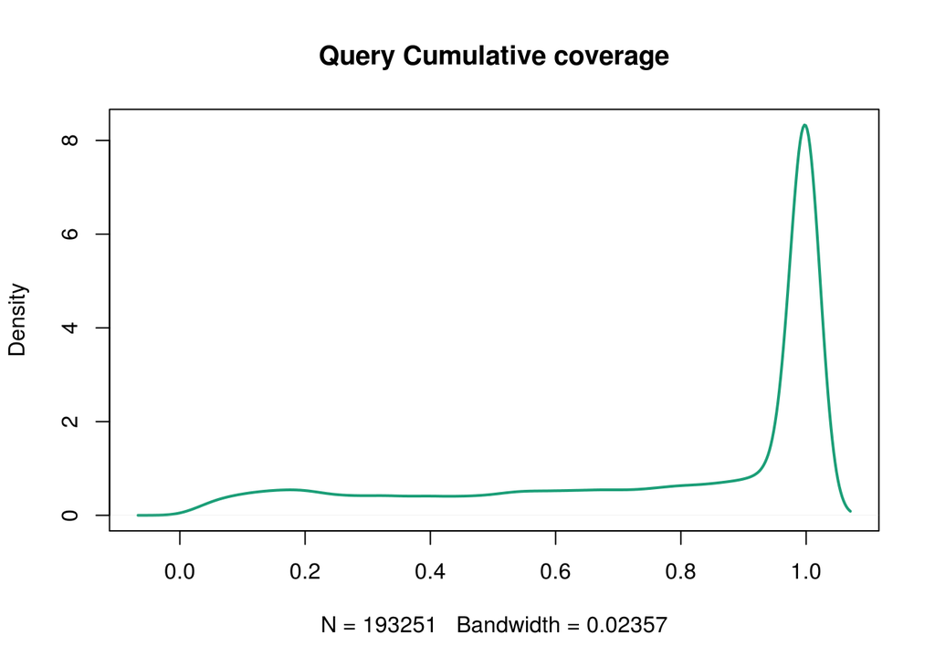

```r
plot(density(f.dat$query.cum.cov),col=pal[1],lwd=2,
     main="Query Cumulative coverage")
```

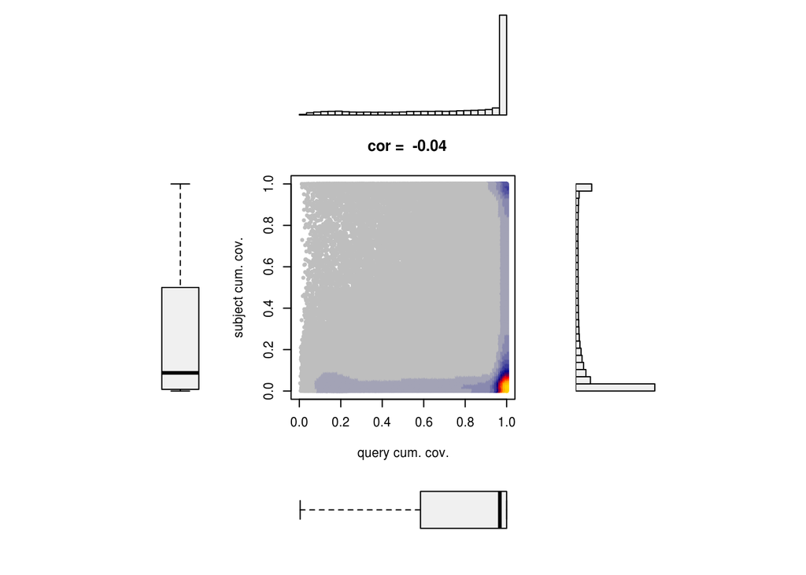

```r
comparisonplot(f.dat$query.cum.cov,f.dat$subject.cum.cov,
               xlab="query cum. cov.",ylab="subject cum. cov.",
               main="")
```

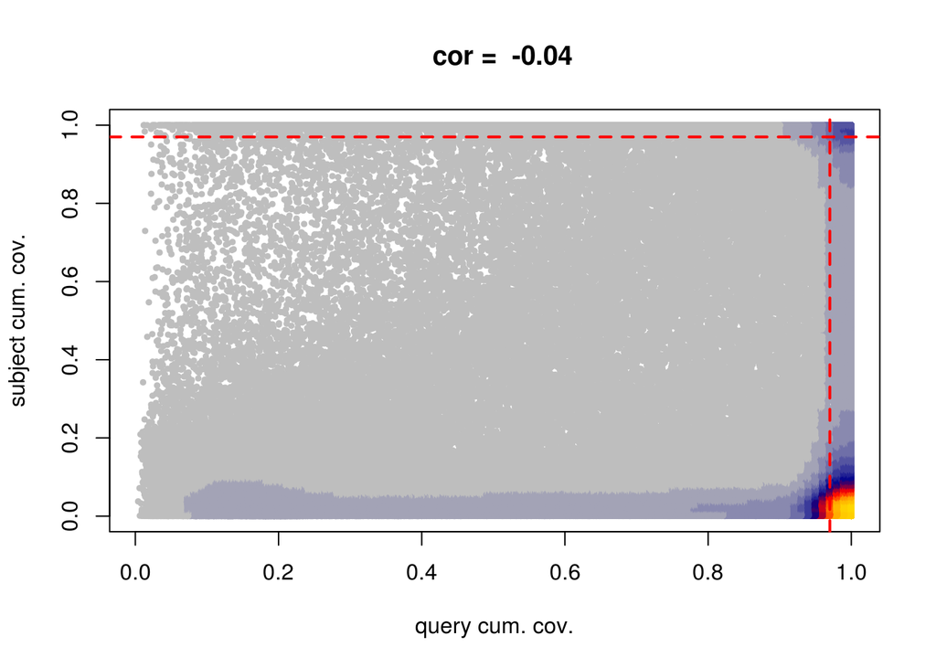

```r
heatscatter(f.dat$query.cum.cov,f.dat$subject.cum.cov,
            xlab="query cum. cov.",ylab="subject cum. cov.",
            main="")

abline(h=0.97,v=0.97,col=2,lty=2,lwd=2)
```

This is more as expected, a lot of small sequences are almost fully covered in big sequences, but there’s otherwise a wide distribution.

```r
sel <- f.dat$query.cum.cov == 1 & f.dat$subject.cum.cov == 1
sprintf("There are %s scaffolds that appear to be fully percent redundant",
        sum(sel))
```

```
## [1] "There are 4018 scaffolds that appear to be fully percent redundant"
```

Let’s look at these in a pairwise alignment fashion. Subset the necessary data

```r
red <- f.dat[sel,]
```

Then load the sequences

```r
seq <- readDNAStringSet("/mnt/picea/storage/reference/Populus-tremula/v1.0/fasta/Potra01-genome.fa")
```

And perform a set if pairwise alignments. This shows the flaw of this approach which has ignored the percentage of identity of the HSPs. It nevertheless revealed that a lot of sequences are contained within other sequence with an high level of identity (>80%). This is a good sign that the assembly managed to integrate a reasonable number of somewhat repetitive elements.

```r
pA <- pairwiseAlignment(reverseComplement(seq[[red[1,2]]]),seq[[red[1,1]]])
length(pattern(pA))
```

```
## [1] 1
```

```r
as.character(pattern(pA))
```

```
## [1] "TCAAAGCGTTTCGCCGTTTGCGGAAGGAAGTCTGATGTAGAACAACTAGCAGAAACATAC…---------------------------------------------------------------------------------------------------------------------------------------------------TTTCGGCAACCGGGGCATCAAAA-------------------------------------------------------TTGGAA…
```

```r
as.character(subject(pA))
```

```
## [1] "TCAAAGCGTTTAGCCGTTTGCGGAAGAAAATCTGATGTAGAACAAGTT-CAGAAGCATACATGCTCCAGAGGGATCACCCGAAATTCAATTGCAACTGAATTTCGGCAA…"
```

```r
nchar(pA)
```

```
## [1] 1004
```

```r
length(mismatch(subject(pA))[[1]])
```

```
## [1] 77
```

```r
length(mismatch(pattern(pA))[[1]])
```

```
## [1] 77
```

```r
indel(pA)
```

```
## An object of class "InDel"
## Slot "insertion":
## IRangesList of length 1
## [[1]]
## IRanges of length 1
##     start end width
## [1]    49  49     1
##
##
## Slot "deletion":
## IRangesList of length 1
## [[1]]
## IRanges of length 4
##     start end width
## [1]   397 543   147
## [2]   420 474    55
## [3]   493 493     1
## [4]   620 766   147
```

# 4 Second attempt

This attempt is based on filtering the HSPs based on their percentage of identity and then construct the cumulative coverage as done in the first attempt.

```r
blt <- do.call(rbind,mclapply(dir(".",pattern=".*\\.blt"),
                function(fil){
                  readBlast(fil,ignoreSelf = TRUE,
                            format=c("query.id",
                                     "subject.id",
                                     "percent.identity",
                                     "alignment.length",
                                     "mismatches",
                                     "gap.opening",
                                     "query.start",
                                     "query.end",
                                     "subject.start",
                                     "subject.end",
                                     "e.value",
                                     "bit.score",
                                     "query.length",
                                     "subject.length"),
                            plot = FALSE)$blf},mc.cores=4L))
```

Reading the chunks is fast but combining the final results takes a while, it might be worth to integrate the percent identity filtering in the blastUtility.R helper.

The overall density of the percentage identity of all the HSPs is as follows. It is really interesting to observe these very defined peaks towards the right end of the graph. We have a number of perfect hits, some more hits around 97% identity (possible haplotypes), a tinier peak at 95% and a shoulder around 93%. The bulge of the remaining hits centers around 88%. The peak intervals are surprisingly constant and agrees well with the estimated heterozygosity rate. Concerning the peaks lower than 97%, this could lead to wild hypotheses :-)

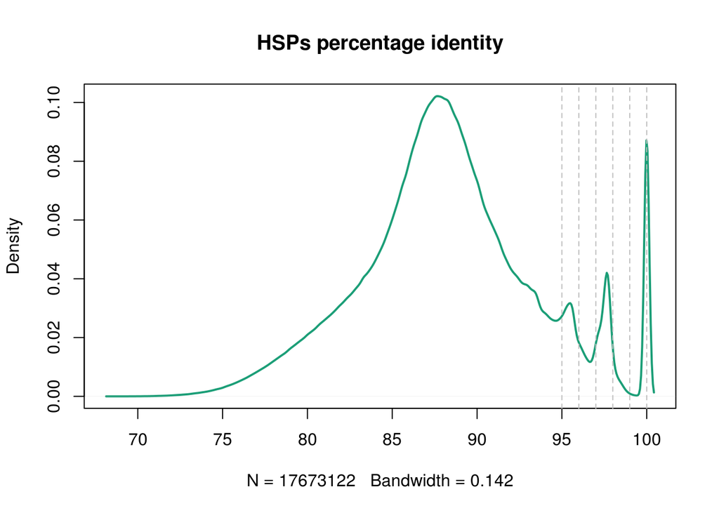

```r
plot(density(blt$percent.identity),main="HSPs percentage identity",
     col=pal[1],lwd=2)
abline(v=c(95:100),lty=2,col="grey")
```

Next we define a function (which should be integrated in the blastUtility,R) that filters HSPs based on percent identity and calculate and sort the obtained cumulative coverage

```r
getCumulativeCoverage <- function(blt,perc.ident=95){
  blf <- blt[blt$percent.identity>=perc.ident,]

  ids <- paste(blf$query.id,blf$subject.id,sep="+")
  suids <- sort(unique(ids))

  df <- data.frame(query.id=sub("\\+.*","",suids),
                   subject.id=sub(".*\\+","",suids),
                   query.cum.cov=sum(width(reduce(split(
                     IRanges(
                       start=ifelse(blf$query.start>blf$query.end,blf$query.end,blf$query.start),
                       end=ifelse(blf$query.start<blf$query.end,blf$query.end,blf$query.start)),
                     ids))))/blf$query.length[match(sub("\\+.*","",suids),blf$query.id)],
                   subject.cum.cov=sum(width(reduce(split(
                     IRanges(
                       start=ifelse(blf$subject.start>blf$subject.end,blf$subject.end,blf$subject.start),
                       end=ifelse(blf$subject.start<blf$subject.end,blf$subject.end,blf$subject.start)),
                     ids))))/blf$subject.length[match(sub(".*\\+","",suids),blf$subject.id)],
                   stringsAsFactors=FALSE)

  return(df[order(df$query.cum.cov,df$subject.cum.cov,decreasing=TRUE),])
}
```

Now iteratively get the cumulative coverage

```r
res <- mclapply(seq(95,100,1),function(p,blt){
  return(getCumulativeCoverage(blt,p))
},blt,mc.cores=6L)
names(res) <- paste("Perc","Ident",seq(95,100,1),sep=".")
```

And have a look at the number of scaffold pairs linked by HSPs

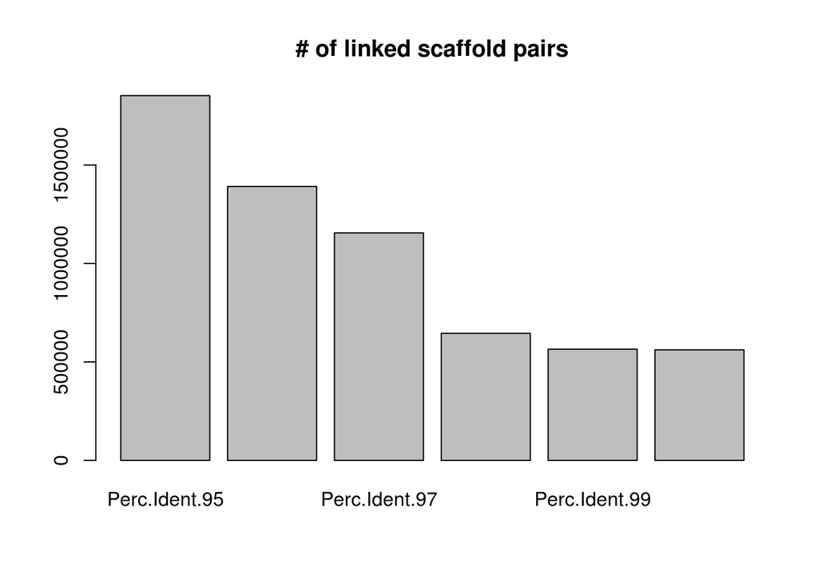

```r
barplot(sapply(res,nrow),main="# of linked scaffold pairs")
```

Have a look at the relationship query - subject coverage

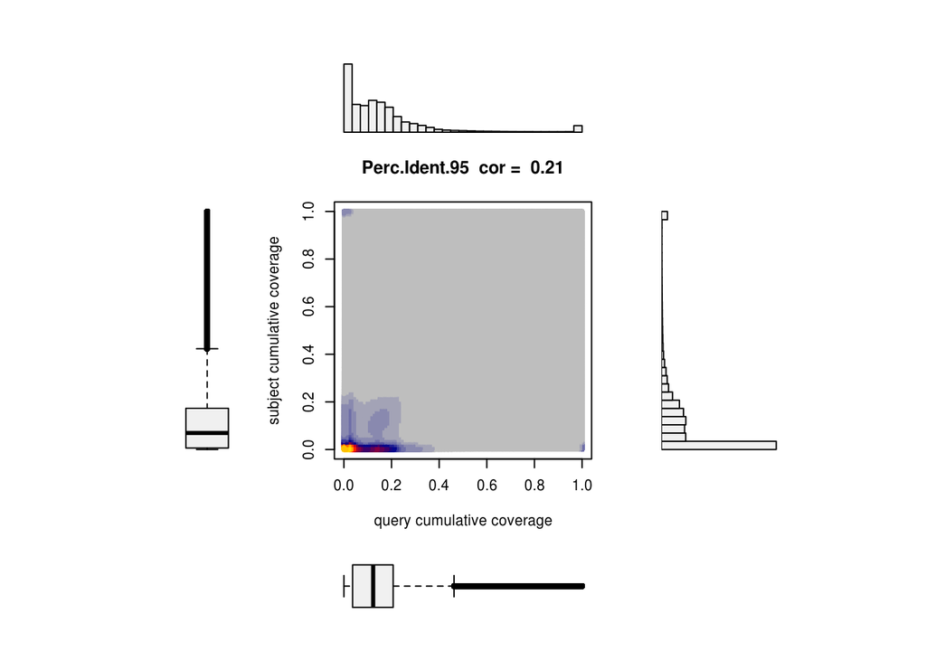

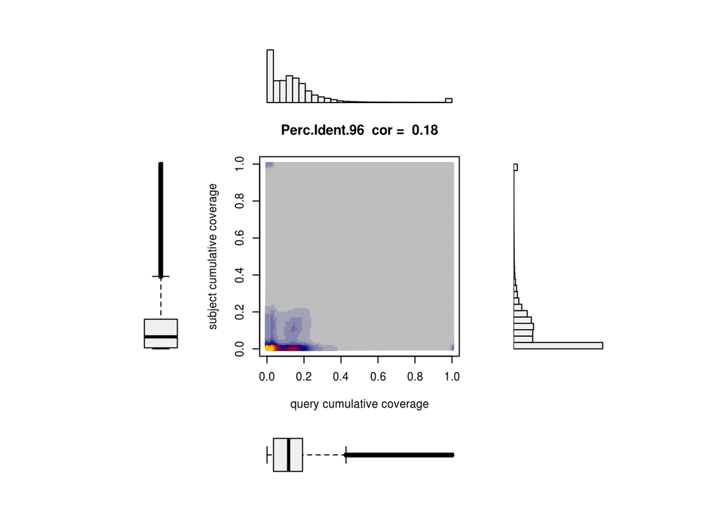

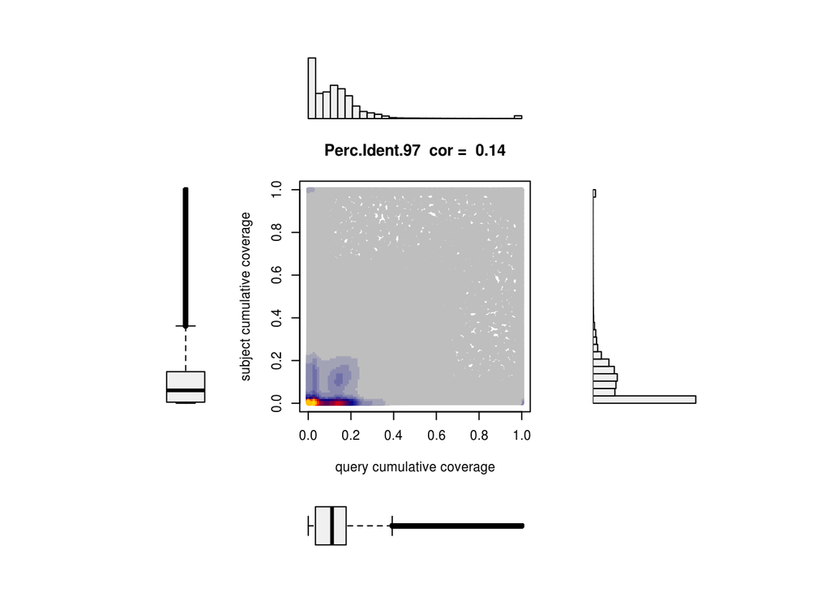

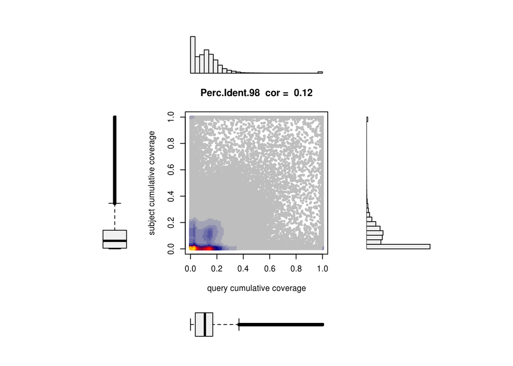

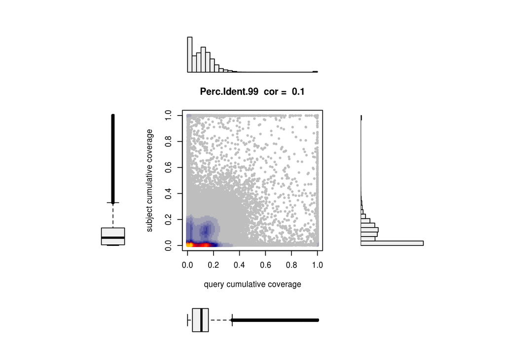

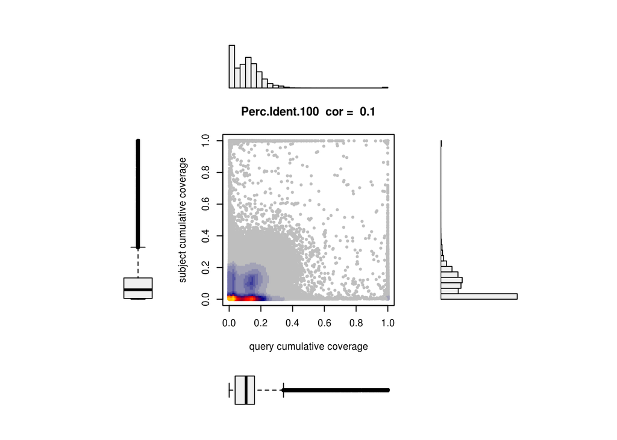

```r
dev.null <- sapply(1:length(res),function(i,res){
  re <- res[[i]]
  comparisonplot(re$query.cum.cov,
                 re$subject.cum.cov,
                 xlab="query cumulative coverage",
                 ylab="subject cumulative coverage",
                 main=names(res)[i])
},res)
```

Have a look at number of unique scaffolds involved

```r
scfs <- lapply(1:length(res),function(i,res){
  re <- res[[i]]
  unique(sort(c(re$query.id,re$subject.id)))
},res)
names(scfs) <- names(res)
```

And how do they overlap? As expected the lower percent identity contains all the others and the amount of scaffolds decreases with increasing identity. Nevertheless the vast majority of scaffolds is present at a 100% identity.

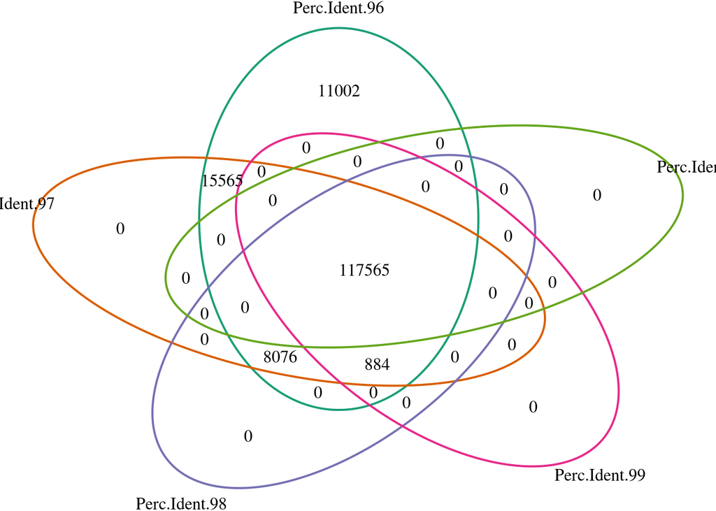

```r
plot.new()
grid.draw(venn.diagram(scfs[2:6],
                       filename=NULL,
                       col=pal[1:5],
                       category.names=names(scfs)[2:6])
)
```

Let us use the subset of 100% identity to identify redundant and artefactual scaffolds; i.e. those having a 100% query cumulative coverage (redundant). If the subject cumulative coverage is also a 100%, then there are considered artifacts.

```r
sel <- res[["Perc.Ident.100"]]$query.cum.cov == 1
sprintf("There are %s scaffolds that are redundant",sum(sel))
```

```
## [1] "There are 2340 scaffolds that are redundant"
```

Most of them are contained

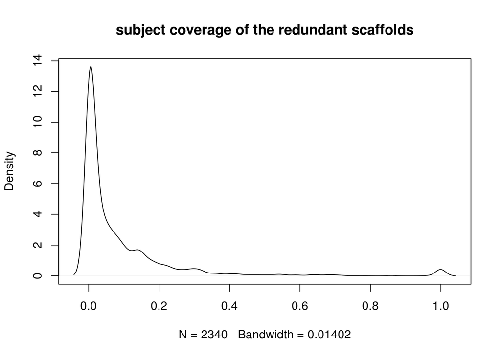

```r
plot(density(res[["Perc.Ident.100"]]$subject.cum.cov[sel]),
     main="subject coverage of the redundant scaffolds")
```

And a few are redundant

```r
sel <- sel & res[["Perc.Ident.100"]]$subject.cum.cov == 1
sprintf("%s of which are artefactual",sum(sel))
```

```
## [1] "32 of which are artefactual"
```

Extend the annotation

```r
annot <- read.delim("../../asp201/genome/annotation/Potra01-meta-matrix.tsv")
annot <- annot[,- grep("redund",colnames(annot))]
annot$redundant <- annot$ID %in%
  res[["Perc.Ident.100"]]$query.id[res[["Perc.Ident.100"]]$query.cum.cov == 1]
annot$artefactual <- annot$ID %in%
  res[["Perc.Ident.100"]]$query.id[res[["Perc.Ident.100"]]$query.cum.cov == 1
                                   & res[["Perc.Ident.100"]]$subject.cum.cov == 1]
```

Use a value of 97% identity and 97% coverage Note that some scaffolds will be duplicated - i.e. have several hits. We only report the best one here.

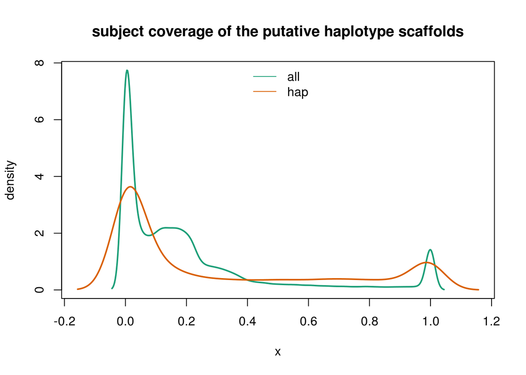

```r
dat <- res[["Perc.Ident.97"]]
sel <- match(annot$ID,dat$query.id)
annot$haplotype.ID <- dat$subject.id[sel]
annot$haplotype.query.cum.cov <- dat$query.cum.cov[sel]
annot$haplotype.subject.cum.cov <- dat$subject.cum.cov[sel]
annot$putative.haplotype <- annot$haplotype.query.cum.cov >= 0.97
sel <- annot$putative.haplotype & ! is.na(annot$putative.haplotype) & ! annot$redundant

plot.multidensity(list(all=na.omit(annot$haplotype.subject.cum.cov),
                       hap=annot$haplotype.subject.cum.cov[sel]),
     main="subject coverage of the putative haplotype scaffolds",lwd=2)
```

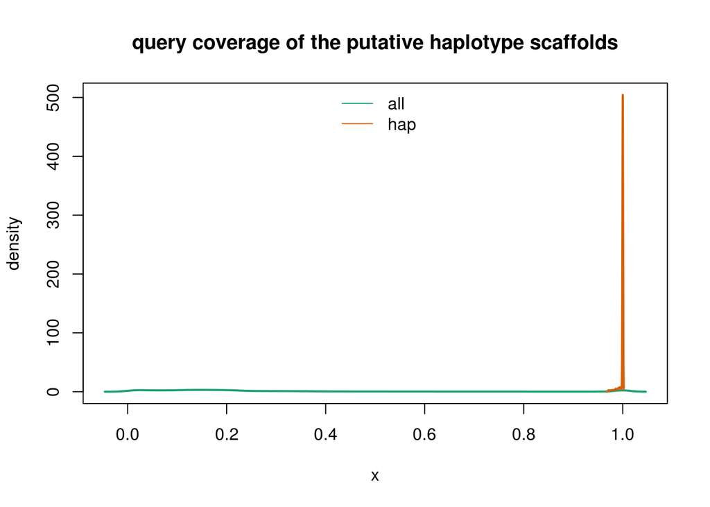

```r
plot.multidensity(list(all=na.omit(annot$haplotype.query.cum.cov),
                       hap=annot$haplotype.query.cum.cov[sel]),
     main="query coverage of the putative haplotype scaffolds",lwd=2)
```

```r
sprintf("There are %s putative haplotype scaffolds",sum(sel))
```

```
## [1] "There are 10064 putative haplotype scaffolds"
```

# 5 Save annotation

```r
write.table(annot,"row.names"=FALSE,quote=FALSE,
            sep="\t",file="../../asp201/genome/annotation/Potra01-meta-matrix.tsv")
```